# Untitled

Eliane,Henrique,Guilherme Pazian,Murilo

2 de novembro de 2016

**#Lista 3**

# Exercício 3

```r
#leitura dos dados
censo = read.table("http://www.ime.unicamp.br/~cnaber/censo.txt")
names(censo)=c("Estado","Anos_escolaridade","Renda_media")
censo
```

```
##    Estado Anos_escolaridade Renda_media
## 1      RR               5.7         685
## 2      AP               6.0         683
## 3      AC               4.5         526
## 4      RO               4.9         662
## 5      PA               4.7         536
## 6      AM               5.5         627
## 7      TO               4.5         520
## 8      PB               3.9         423
## 9      MA               3.6         343
## 10     RN               4.5         513
## 11     SE               4.3         462
## 12     PI               3.5         383
## 13     BA               4.1         460
## 14     PE               4.6         517
## 15     AL               3.7         454
## 16     CE               4.0         448
## 17     SP               6.8        1076
## 18     RJ               7.1         970
## 19     ES               5.7         722
## 20     MG               5.4         681
## 21     SC               6.3         814
## 22     RS               6.4         800
## 23     PR               6.0         782
## 24     MT               5.4         775
## 25     GO               5.5         689
## 26     MS               5.7         731
## 27     DF               8.2        1499
```

### Análise descritiva

#### Gráfico

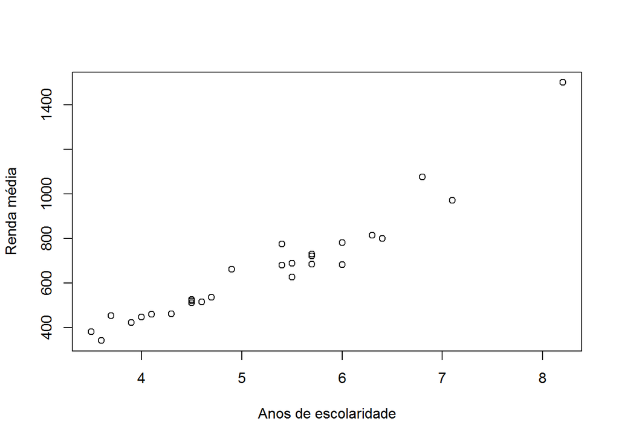

```r
plot(censo$Anos_escolaridade,censo$Renda_media,xlab="Anos de escolaridade",ylab="Renda média")
```

### Modelos

Dada a natureza dos dados, como vista no gráfico acima, proporá-se dois modelos, um linear e outro quadrado

#### Modelo 1 (Linear)

$$y_{i}=\beta_{0}+\beta_{1}x_{i}+e_{i}$$

##### Ajuste

```r
modelo1 = lm(censo$Renda_media~censo$Anos_escolaridade)
summary(modelo1)
```

```
##
## Call:
## lm(formula = censo$Renda_media ~ censo$Anos_escolaridade)
##
## Residuals:
##     Min      1Q  Median      3Q     Max
## -134.68  -35.70  -15.97   27.47  241.70
##
## Coefficients:
##                         Estimate Std. Error t value Pr(>|t|)
## (Intercept)              -381.28      69.40  -5.494 1.05e-05 ***
## censo$Anos_escolaridade   199.83      13.03  15.338 3.17e-14 ***
## ---
## Signif. codes:  0 '***' 0.001 '**' 0.01 '*' 0.05 '.' 0.1 ' ' 1
##
## Residual standard error: 77.22 on 25 degrees of freedom
## Multiple R-squared:  0.9039, Adjusted R-squared:  0.9001
## F-statistic: 235.3 on 1 and 25 DF,  p-value: 3.167e-14
```

##### Análise Residual

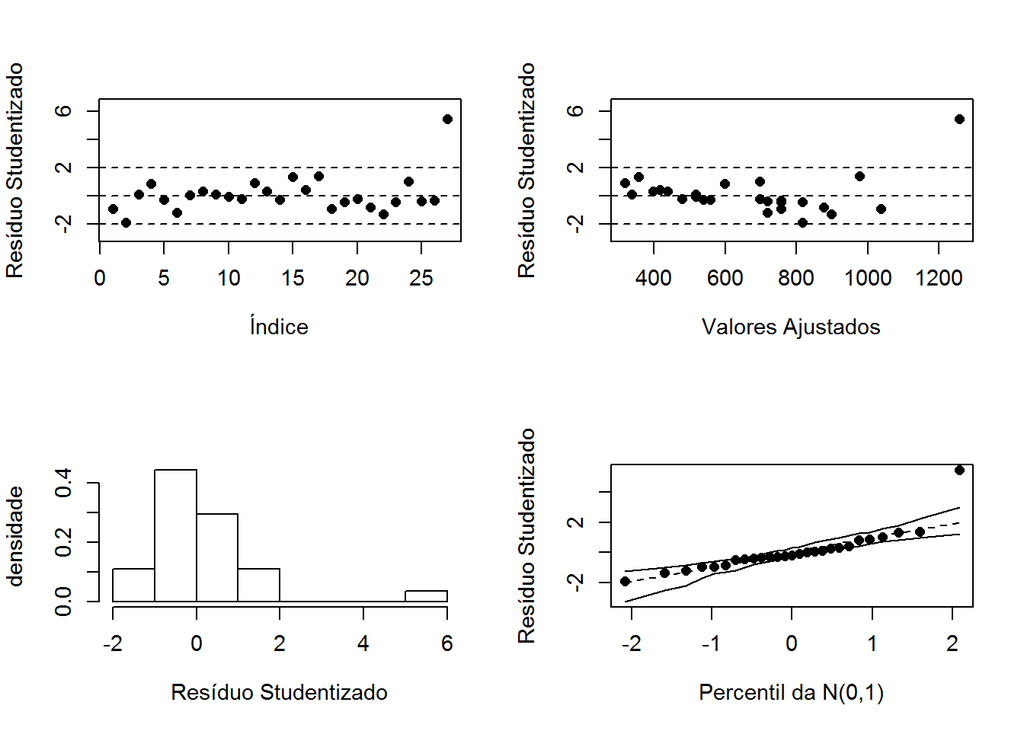

```r
diagnorm(modelo1)
```

1. Presença de Heterocedasticidade (Vista no gráfico Valores Ajustados x Resíduos Studentalizados)
2. Possível não normalidade dos dados (Vista no gráfico Resíduo Studentalizado x densidade)

#### Modelo 2 (Quadrado)

$$y_{i}=\beta_{0}+\beta_{1}x_{i}+\beta_{2}x_{i}^{2}+e_{i}$$

**Ajuste**

```r
a2 = (censo$Anos_escolaridade)^2
modelo2=lm(censo$Renda_media~censo$Anos_escolaridade+a2)
summary(modelo2)
```

```
##
## Call:
## lm(formula = censo$Renda_media ~ censo$Anos_escolaridade + a2)
##
## Residuals:
##      Min       1Q   Median       3Q      Max
## -102.264  -24.890    1.764   18.257  121.497
##
## Coefficients:
##                         Estimate Std. Error t value Pr(>|t|)
## (Intercept)              546.982    196.802   2.779   0.0104 *
## censo$Anos_escolaridade -152.620     72.863  -2.095   0.0469 *
## a2                        31.916      6.543   4.878 5.66e-05 ***
## ---
## Signif. codes:  0 '***' 0.001 '**' 0.01 '*' 0.05 '.' 0.1 ' ' 1
##
## Residual standard error: 55.85 on 24 degrees of freedom
## Multiple R-squared:  0.9518, Adjusted R-squared:  0.9477
## F-statistic: 236.8 on 2 and 24 DF,  p-value: < 2.2e-16
```

**Análise Residual**:

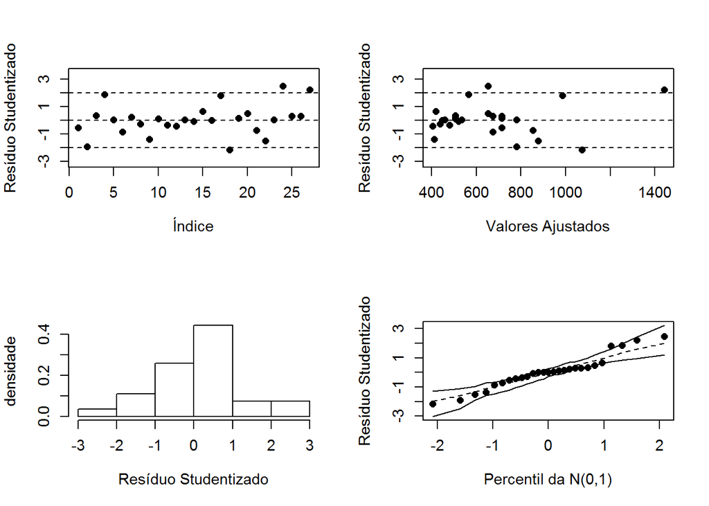

```r
diagnorm(modelo2)
```

1. Presença de Heterocedasticidade (Vista no gráfico Valores Ajustados x Resíduos Studentalizados)
2. Possível não normalidade dos dados (Vista no gráfico Resíduo Studentalizado x densidade)

**AIC,BIC e Teste da Razão de Verossimilhança**:

```r
library(printr)
estat_test =  data.frame(rbind(AIC(modelo1),BIC(modelo1),logLik(modelo1)),rbind(AIC(modelo2),BIC(modelo2),logLik(modelo2)))
rownames(estat_test)=c("AIC","BIC","Log-Verosi")
colnames(estat_test)=c("Modelo1","Modelo2")
estat_test
```

|  | Modelo1 | Modelo2 |
| --- | --- | --- |
| AIC | 315.2632 | 298.6633 |
| BIC | 319.1507 | 303.8466 |
| Log-Verosi | -154.6316 | -145.3316 |

Pelas análises de **AIC** e do **BIC**, observa-se que o segundo modelo proposto é o melhor a se utilizado pois os valores das estastísticas são menores(Quanto menor, melhor).

# Exercício 4

```r
dados_imoveis = read.table("http://www.ime.unicamp.br/~cnaber/imoveis.txt",)
names(dados_imoveis) <- c("imposto do imóvel","área do terreno","área construída","idade da residência","preço de venda do imóvel")
dados_imoveis
```

| imposto do imóvel | área do terreno | área construída | idade da residência | preço de venda do imóvel |
| --- | --- | --- | --- | --- |
| 4.9176 | 3.4720 | 0.998 | 42 | 25.9 |
| 5.0208 | 3.5310 | 1.500 | 62 | 29.5 |
| 4.5429 | 2.2750 | 1.175 | 40 | 27.9 |
| 4.5573 | 4.0500 | 1.232 | 54 | 25.9 |
| 5.0597 | 4.4550 | 1.121 | 42 | 29.9 |
| 3.8910 | 4.4550 | 0.988 | 56 | 29.9 |
| 5.8980 | 5.8500 | 1.240 | 51 | 30.9 |
| 5.6039 | 9.5200 | 1.501 | 32 | 28.9 |
| 15.4202 | 9.8000 | 3.420 | 42 | 84.9 |
| 14.4598 | 12.8000 | 3.000 | 14 | 82.9 |
| 5.8282 | 6.4350 | 1.225 | 32 | 35.9 |
| 5.3003 | 4.9883 | 1.552 | 30 | 31.5 |
| 6.2712 | 5.5200 | 0.975 | 30 | 31.0 |
| 5.9592 | 6.6660 | 1.121 | 32 | 30.9 |
| 5.0500 | 5.0000 | 1.020 | 46 | 30.0 |
| 8.2464 | 5.1500 | 1.664 | 50 | 36.9 |
| 6.6969 | 6.9020 | 1.488 | 22 | 41.9 |
| 7.7841 | 7.1020 | 1.376 | 17 | 40.5 |
| 9.0384 | 7.8000 | 1.500 | 23 | 43.9 |
| 5.9894 | 5.5200 | 1.256 | 40 | 37.5 |
| 7.5422 | 4.0000 | 1.690 | 22 | 37.9 |
| 8.7951 | 9.8900 | 1.820 | 50 | 44.5 |
| 6.0931 | 6.7265 | 1.652 | 44 | 37.9 |
| 8.3607 | 9.1500 | 1.777 | 48 | 38.9 |
| 8.1400 | 8.0000 | 1.504 | 3 | 36.9 |
| 9.1416 | 7.3262 | 1.831 | 31 | 45.8 |
| 12.0000 | 5.0000 | 1.200 | 30 | 41.0 |

[figure not shown]

```r
par(mfrow=c(2,2))
plot(dados_imoveis$`preço de venda do imóvel`,dados_imoveis$`imposto do imóvel`,ylab = "preço de venda do imóvel (em 1000 USD)",xlab = "imposto do imóvel (em 100 USD)")
plot(dados_imoveis$`preço de venda do imóvel`,dados_imoveis$`área do terreno`,ylab = "preço de venda do imóvel (em 1000 USD)",xlab = "área do terreno (em 1000 pés quadrados)")
plot(dados_imoveis$`preço de venda do imóvel`,dados_imoveis$`área construída`,ylab = "preço de venda do imóvel (em 1000 USD)",xlab = "área construída (em 1000 pés quadrados)")
plot(dados_imoveis$`preço de venda do imóvel`,dados_imoveis$`idade da residência`,ylab = "preço de venda do imóvel (em 1000 USD)",xlab = "idade da residência (em anos)")
```

Note que parece razoável modelar os dados via modelo de regressão linear múltipla. Conforme sugerido (no ex 6 da lista 2), vamos modela-los, inicialmente, por 4 retas. Dado a natureza dos dados (unidades diferentes) vamos utilizar o seguinte modelo:

$$y_{ij}=\beta_{0}+\beta_{1i}\left(\frac{x_{ij}-\bar{x}_i}{s_i}\right) +e_{ij}$$

$\beta_{0}$ = valor esperado no valor da venda para $y_{ij}$ quando os $x_{ij}$ têm valores iguais as respectivas médias $\bar{x_i}$ . **#Dúvida (conferir a interpretação)**

$\frac{\beta_{1i}}{s_i}$ = incremento (+/-) quando se aumenta o valor de $x_{ij}$ em uma unidade (mantendo-se as demais variáveis fixas).

```r
medias = lapply(dados_imoveis,mean)
se = lapply(dados_imoveis,sd)
processed.dados_imoveis <- dados_imoveis

#colocando os dados na mesma escala:

processed.dados_imoveis$`imposto do imóvel` <- (dados_imoveis$`imposto do imóvel`-medias$`imposto do imóvel`)/se$`imposto do imóvel`

processed.dados_imoveis$`área do terreno`<-(dados_imoveis$`área do terreno`- medias$`área do terreno`)/se$`área do terreno`

processed.dados_imoveis$`área construída` <- (dados_imoveis$`área construída`- medias$`área construída`)/se$`área construída`

processed.dados_imoveis$`idade da residência` <- (dados_imoveis$`idade da residência`-medias$`idade da residência`)/se$`idade da residência`

processed.dados_imoveis
```

| imposto do imóvel | área do terreno | área construída | idade da residência | preço de venda do imóvel |
| --- | --- | --- | --- | --- |
| -0.8074350 | -1.1963155 | -0.9208421 | 0.3926901 | 25.9 |
| -0.7716283 | -1.1717698 | -0.0216278 | 1.8158621 | 29.5 |
| -0.9374426 | -1.6943026 | -0.6037885 | 0.2503729 | 27.9 |
| -0.9324463 | -0.9558505 | -0.5016865 | 1.2465933 | 25.9 |
| -0.7581314 | -0.7873586 | -0.7005167 | 0.3926901 | 29.9 |
| -1.1636287 | -0.7873586 | -0.9387547 | 1.3889105 | 29.9 |
| -0.4672711 | -0.2069977 | -0.4873564 | 1.0331175 | 30.9 |
| -0.5693133 | 1.3198300 | -0.0198366 | -0.3188960 | 28.9 |
| 2.8365934 | 1.4363182 | 3.4175980 | 0.3926901 | 84.9 |
| 2.5033688 | 2.6844062 | 2.6652674 | -1.5997508 | 82.9 |
| -0.4914892 | 0.0363795 | -0.5142253 | -0.3188960 | 35.9 |
| -0.6746517 | -0.5654902 | 0.0715179 | -0.4612132 | 31.5 |
| -0.3377840 | -0.3442874 | -0.9620412 | -0.4612132 | 31.0 |
| -0.4460369 | 0.1324822 | -0.7005167 | -0.3188960 | 30.9 |
| -0.7614969 | -0.5606227 | -0.8814343 | 0.6773245 | 30.0 |
| 0.3475401 | -0.4982182 | 0.2721394 | 0.9619589 | 36.9 |
| -0.1900812 | 0.2306652 | -0.0431230 | -1.0304820 | 41.9 |
| 0.1871385 | 0.3138710 | -0.2437445 | -1.3862750 | 40.5 |
| 0.6223359 | 0.6042595 | -0.0216278 | -0.9593234 | 43.9 |
| -0.4355586 | -0.3442874 | -0.4586961 | 0.2503729 | 37.5 |
| 0.1032078 | -0.9766520 | 0.3187122 | -1.0304820 | 37.9 |
| 0.5379195 | 1.4737608 | 0.5515765 | 0.9619589 | 44.5 |
| -0.3995783 | 0.1576520 | 0.2506442 | 0.5350073 | 37.9 |
| 0.3871981 | 1.1658991 | 0.4745521 | 0.8196417 | 38.9 |
| 0.3106231 | 0.6874654 | -0.0144628 | -2.3824955 | 36.9 |
| 0.6581426 | 0.4071448 | 0.5712804 | -0.3900546 | 45.8 |
| 1.6499057 | -0.5606227 | -0.5590069 | -0.4612132 | 41.0 |

Note que a análise descritiva para os dados transformados $x_{ij} = \frac{x_{ij}-\bar{x}_i}{s_i}$ é equivalente à análise anterior (dados não transformados)

[figure not shown]

```r
par(mfrow=c(2,2))
plot(dados_imoveis$`preço de venda do imóvel`,processed.dados_imoveis$`imposto do imóvel`,ylab = "preço de venda do imóvel (em 1000 USD)",xlab = "imposto do imóvel (sem unidade)")
plot(dados_imoveis$`preço de venda do imóvel`,processed.dados_imoveis$`área do terreno`,ylab = "preço de venda do imóvel (em 1000 USD)",xlab = "área do terreno (sem unidade)")
plot(dados_imoveis$`preço de venda do imóvel`,processed.dados_imoveis$`área construída`,ylab = "preço de venda do imóvel (em 1000 USD)",xlab = "área construída (sem unidade)")
plot(dados_imoveis$`preço de venda do imóvel`,processed.dados_imoveis$`idade da residência`,ylab = "preço de venda do imóvel (em 1000 USD)",xlab = "idade da residência (sem unidade)")
```

##Modelo

```r
fit.processed.dados_imoveis <- lm(processed.dados_imoveis$`preço de venda do imóvel`~processed.dados_imoveis$`imposto do imóvel`+processed.dados_imoveis$`área do terreno`+processed.dados_imoveis$`área construída`+processed.dados_imoveis$`idade da residência`)
```

Analise Residual:

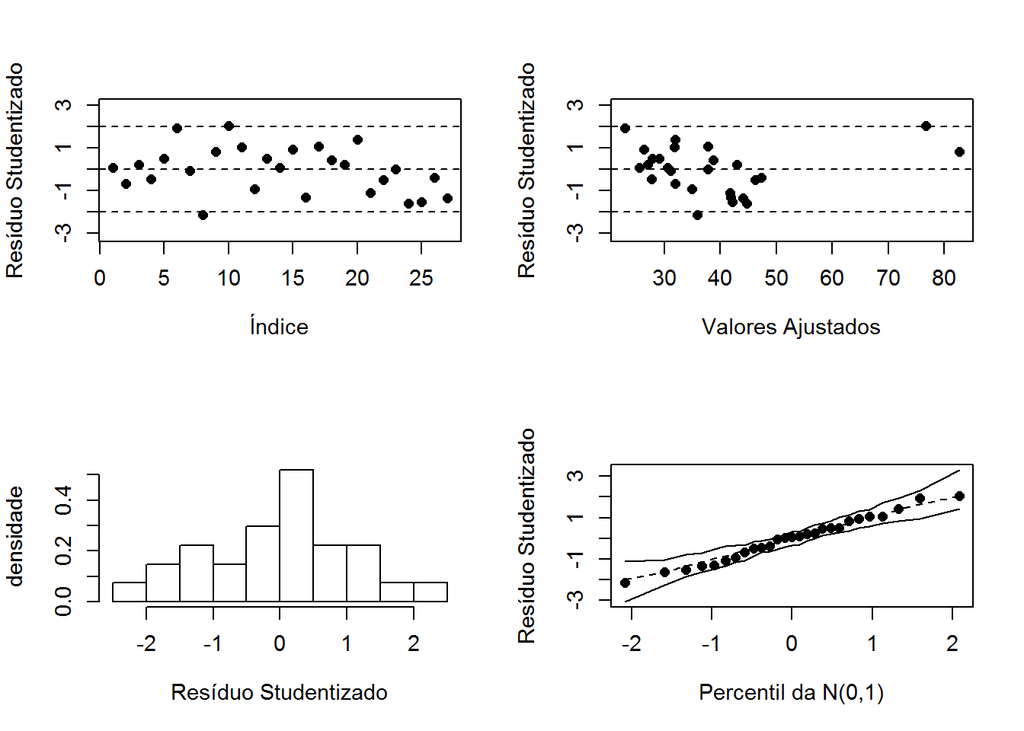

```r
diagnorm(fit.processed.dados_imoveis)
```

Resultados do ajuste:

```r
results.fit.imoveis <- data.frame(summary(fit.processed.dados_imoveis)$coefficients)

LIICs <-  results.fit.imoveis$Estimate - qnorm(0.975)*results.fit.imoveis$Std..Error

LSICs <- results.fit.imoveis$Estimate + qnorm(0.975)*results.fit.imoveis$Std..Error

tbl.fit.imoveis <- data.frame(cbind(results.fit.imoveis,LIICs,LSICs))
colnames(tbl.fit.imoveis) <- c("Estimativa","Erro-padrão","Estat.t","p-valor","Limite inferior IC(95%)","Limite superior IC(95%)")
rownames(tbl.fit.imoveis) <- c("B_0","B_1","B_2","B_3","B_4")
tbl.fit.imoveis
```

|  | Estimativa | Erro-padrão | Estat.t | p-valor | Limite inferior IC(95%) | Limite superior IC(95%) |
| --- | --- | --- | --- | --- | --- | --- |
| B_0 | 38.5000000 | 0.7845719 | 49.0713462 | 0.0000000 | 36.962267 | 40.037733 |
| B_1 | 5.9897634 | 1.5937120 | 3.7583726 | 0.0010853 | 2.866145 | 9.113381 |
| B_2 | 0.5585577 | 1.2176534 | 0.4587165 | 0.6509374 | -1.827999 | 2.945115 |
| B_3 | 7.8010887 | 1.6226692 | 4.8075657 | 0.0000840 | 4.620716 | 10.981462 |
| B_4 | -0.6150284 | 0.9314992 | -0.6602565 | 0.5159433 | -2.440733 | 1.210676 |

Observando os p-valores para o teste de nulidade, concluimos que os parâmetros $B_2$ e $B_4$ não são significativos, ou seja, podemos utilizar um moledo reduzido excluindo do modelo as variáveis “área do terreno” e “idade da residência”

## Modelo Reduzido

```r
fit2.processed.dados_imoveis <- lm(processed.dados_imoveis$`preço de venda do imóvel`~processed.dados_imoveis$`imposto do imóvel`+processed.dados_imoveis$`área construída`)
```

Analise Residual:

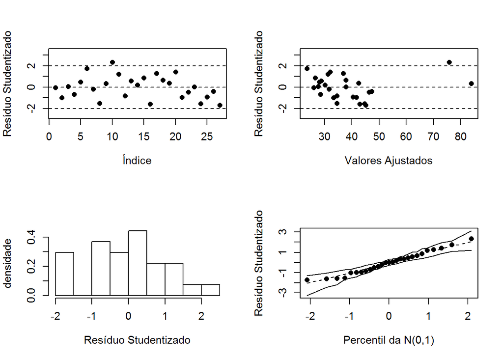

```r
diagnorm(fit2.processed.dados_imoveis)
```

```r
results.fit2.imoveis <- data.frame(summary(fit2.processed.dados_imoveis)$coefficients)

LIICs <-  results.fit2.imoveis$Estimate - qnorm(0.975)*results.fit2.imoveis$Std..Error

LSICs <- results.fit2.imoveis$Estimate + qnorm(0.975)*results.fit2.imoveis$Std..Error

tbl.fit2.imoveis <- data.frame(cbind(results.fit2.imoveis,LIICs,LSICs))
colnames(tbl.fit2.imoveis) <- c("Estimativa","Erro-padrão","Estat.t","p-valor","Limite inferior IC(95%)","Limite superior IC(95%)")
rownames(tbl.fit2.imoveis) <- c("B_0","B_1","B_3")
tbl.fit2.imoveis
```

|  | Estimativa | Erro-padrão | Estat.t | p-valor | Limite inferior IC(95%) | Limite superior IC(95%) |
| --- | --- | --- | --- | --- | --- | --- |
| B_0 | 38.500000 | 0.7664261 | 50.233153 | 0.00e+00 | 36.997832 | 40.002168 |
| B_1 | 6.620443 | 1.4092823 | 4.697741 | 8.96e-05 | 3.858300 | 9.382585 |
| B_3 | 7.778449 | 1.4092823 | 5.519440 | 1.12e-05 | 5.016306 | 10.540591 |

## Teste CB

Consideremos a seguinte Hipótese

$$\beta_1=\beta_3$$
Utilizaremos o teste $C\beta=0$ com:
$$C=\begin{bmatrix}
0 & 1 & -1\\
\end{bmatrix}$$

```r
c <- t(matrix(c(0,1,-1),3,1))
testeF.CB(fit2.processed.dados_imoveis,c)
```

```
## Estatistica F =  0.18
## pvalor =  0.6716
## Matriz C :
##      [,1] [,2] [,3]
## [1,]    0    1   -1
```

Note que o teste acima indica que $\beta_1 = \beta_3$

# Exercício 5

## Análise Descritiva

### Gráficos

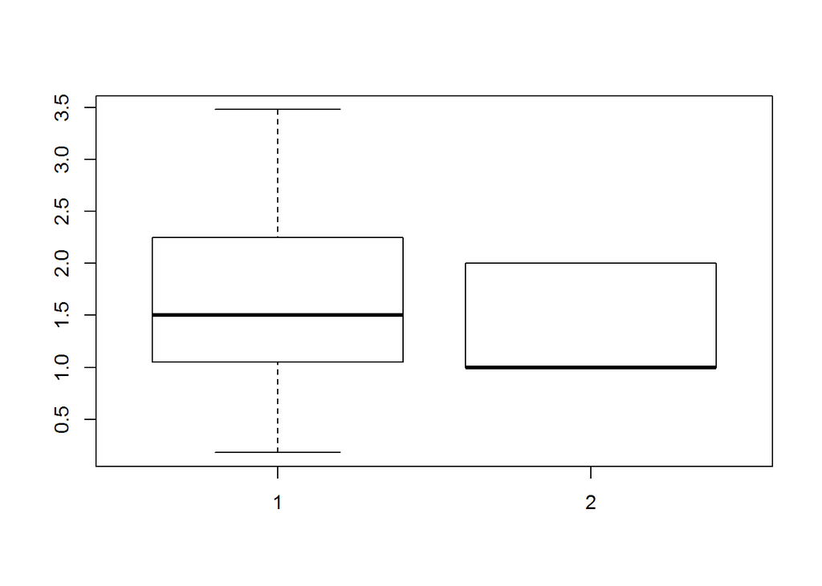

```r
boxplot(dados_escova$`IPB_pré-escovação_escova_Hugger`,dados_escova$sexo)
```

[figure not shown]

[figure not shown]

```r
boxplot(dados_escova$`IPB_pré-escovação_escova_tradicional`,dados_escova$sexo)
```

## Ajuste do Modelo em R

### Ajuste do modelo completo

#### Modelo

$$y_{ijk}=\beta_{0ij}+\beta_{1ij}x_{ijk}+\varepsilon_{ijk}$$

$\beta_{0ij}$:Valor Esperado quando a quantidade de placa for igual a zero($x_{ijk}$=0)

$\beta_{1ij}$:Incremento(+/-) quanto se aumenta uma unidade da variável explicativa

$x_{ijk}$: individuo k que escovou com a escova j e é do sexo i

$\varepsilon_{ijk}$:erro amostral

$\varepsilon_{ijk}\sim \mathit{N}(0,\sigma ^{2})$

```r
result_compl <- lm(ipbpos~-1+sexotescf+(ipbpre:sexotescf))
summary(result_compl)
```

```
##
## Call:
## lm(formula = ipbpos ~ -1 + sexotescf + (ipbpre:sexotescf))
##
## Residuals:
##      Min       1Q   Median       3Q      Max
## -0.57122 -0.12042 -0.00263  0.16182  0.75873
##
## Coefficients:
##                                Estimate Std. Error t value Pr(>|t|)
## sexotescfF.Convencional         0.03224    0.12565   0.257  0.79869
## sexotescfM.Convencional        -0.37832    0.22703  -1.666  0.10274
## sexotescfF.Hugger              -0.06223    0.12919  -0.482  0.63240
## sexotescfM.Hugger               0.06545    0.18508   0.354  0.72531
## sexotescfF.Convencional:ipbpre  0.44494    0.08482   5.246 4.26e-06 ***
## sexotescfM.Convencional:ipbpre  0.51415    0.08126   6.327 1.11e-07 ***
## sexotescfF.Hugger:ipbpre        0.22855    0.07650   2.988  0.00458 **
## sexotescfM.Hugger:ipbpre        0.11725    0.09098   1.289  0.20421
## ---
## Signif. codes:  0 '***' 0.001 '**' 0.01 '*' 0.05 '.' 0.1 ' ' 1
##
## Residual standard error: 0.2506 on 44 degrees of freedom
## Multiple R-squared:  0.8943, Adjusted R-squared:  0.875
## F-statistic: 46.51 on 8 and 44 DF,  p-value: < 2.2e-16
```

Pode-se observar que os interceptos das retas não são significativos, ou seja, a redução de placa é esta´tisticamente igual para índice da placa igual a 0.

Para os coeficientes angulares nota-se que para os casos aonde se escova com a escova convencional, independentemente do sexo e quando as meninas escovam com a escova Hugger que o valor do intercepto é “alto”, ou seja, não houve uma redução drástica de placas quanto houve no caso em que os meninos escovaram com a Hugger.

**Matriz de planejamento**

| ConvencionalF | ConvencionalM | HuggerF | HuggerM | ipbpreConvF | ipbpreConvm | ipbpreHuggerF | ipbprehuggerM |
| --- | --- | --- | --- | --- | --- | --- | --- |
| 1 | 0 | 0 | 0 | 1.20 | 0.00 | 0.00 | 0.00 |
| 1 | 0 | 0 | 0 | 1.43 | 0.00 | 0.00 | 0.00 |
| 1 | 0 | 0 | 0 | 0.68 | 0.00 | 0.00 | 0.00 |
| 1 | 0 | 0 | 0 | 1.45 | 0.00 | 0.00 | 0.00 |
| 1 | 0 | 0 | 0 | 0.50 | 0.00 | 0.00 | 0.00 |
| 1 | 0 | 0 | 0 | 2.75 | 0.00 | 0.00 | 0.00 |
| 1 | 0 | 0 | 0 | 1.25 | 0.00 | 0.00 | 0.00 |
| 1 | 0 | 0 | 0 | 0.40 | 0.00 | 0.00 | 0.00 |
| 1 | 0 | 0 | 0 | 1.18 | 0.00 | 0.00 | 0.00 |
| 1 | 0 | 0 | 0 | 1.43 | 0.00 | 0.00 | 0.00 |
| 1 | 0 | 0 | 0 | 0.45 | 0.00 | 0.00 | 0.00 |
| 1 | 0 | 0 | 0 | 1.60 | 0.00 | 0.00 | 0.00 |
| 1 | 0 | 0 | 0 | 0.25 | 0.00 | 0.00 | 0.00 |
| 1 | 0 | 0 | 0 | 2.98 | 0.00 | 0.00 | 0.00 |
| 0 | 1 | 0 | 0 | 0.00 | 3.35 | 0.00 | 0.00 |
| 0 | 1 | 0 | 0 | 0.00 | 1.50 | 0.00 | 0.00 |
| 0 | 1 | 0 | 0 | 0.00 | 4.08 | 0.00 | 0.00 |
| 0 | 1 | 0 | 0 | 0.00 | 3.15 | 0.00 | 0.00 |
| 0 | 1 | 0 | 0 | 0.00 | 0.90 | 0.00 | 0.00 |
| 0 | 1 | 0 | 0 | 0.00 | 1.78 | 0.00 | 0.00 |
| 0 | 1 | 0 | 0 | 0.00 | 3.50 | 0.00 | 0.00 |
| 0 | 1 | 0 | 0 | 0.00 | 2.50 | 0.00 | 0.00 |
| 0 | 1 | 0 | 0 | 0.00 | 2.18 | 0.00 | 0.00 |
| 0 | 1 | 0 | 0 | 0.00 | 2.68 | 0.00 | 0.00 |
| 0 | 1 | 0 | 0 | 0.00 | 2.73 | 0.00 | 0.00 |
| 0 | 1 | 0 | 0 | 0.00 | 3.43 | 0.00 | 0.00 |
| 0 | 0 | 1 | 0 | 0.00 | 0.00 | 2.18 | 0.00 |
| 0 | 0 | 1 | 0 | 0.00 | 0.00 | 2.05 | 0.00 |
| 0 | 0 | 1 | 0 | 0.00 | 0.00 | 1.05 | 0.00 |
| 0 | 0 | 1 | 0 | 0.00 | 0.00 | 1.95 | 0.00 |
| 0 | 0 | 1 | 0 | 0.00 | 0.00 | 0.28 | 0.00 |
| 0 | 0 | 1 | 0 | 0.00 | 0.00 | 2.63 | 0.00 |
| 0 | 0 | 1 | 0 | 0.00 | 0.00 | 1.50 | 0.00 |
| 0 | 0 | 1 | 0 | 0.00 | 0.00 | 0.45 | 0.00 |
| 0 | 0 | 1 | 0 | 0.00 | 0.00 | 0.70 | 0.00 |
| 0 | 0 | 1 | 0 | 0.00 | 0.00 | 1.30 | 0.00 |
| 0 | 0 | 1 | 0 | 0.00 | 0.00 | 1.25 | 0.00 |
| 0 | 0 | 1 | 0 | 0.00 | 0.00 | 0.18 | 0.00 |
| 0 | 0 | 1 | 0 | 0.00 | 0.00 | 3.30 | 0.00 |
| 0 | 0 | 1 | 0 | 0.00 | 0.00 | 1.40 | 0.00 |
| 0 | 0 | 0 | 1 | 0.00 | 0.00 | 0.00 | 0.90 |
| 0 | 0 | 0 | 1 | 0.00 | 0.00 | 0.00 | 0.58 |
| 0 | 0 | 0 | 1 | 0.00 | 0.00 | 0.00 | 2.50 |
| 0 | 0 | 0 | 1 | 0.00 | 0.00 | 0.00 | 2.25 |
| 0 | 0 | 0 | 1 | 0.00 | 0.00 | 0.00 | 1.53 |
| 0 | 0 | 0 | 1 | 0.00 | 0.00 | 0.00 | 1.43 |
| 0 | 0 | 0 | 1 | 0.00 | 0.00 | 0.00 | 3.48 |
| 0 | 0 | 0 | 1 | 0.00 | 0.00 | 0.00 | 1.80 |
| 0 | 0 | 0 | 1 | 0.00 | 0.00 | 0.00 | 1.50 |
| 0 | 0 | 0 | 1 | 0.00 | 0.00 | 0.00 | 2.55 |
| 0 | 0 | 0 | 1 | 0.00 | 0.00 | 0.00 | 1.30 |
| 0 | 0 | 0 | 1 | 0.00 | 0.00 | 0.00 | 2.65 |

#### Diagnóstico

##### Gráfico

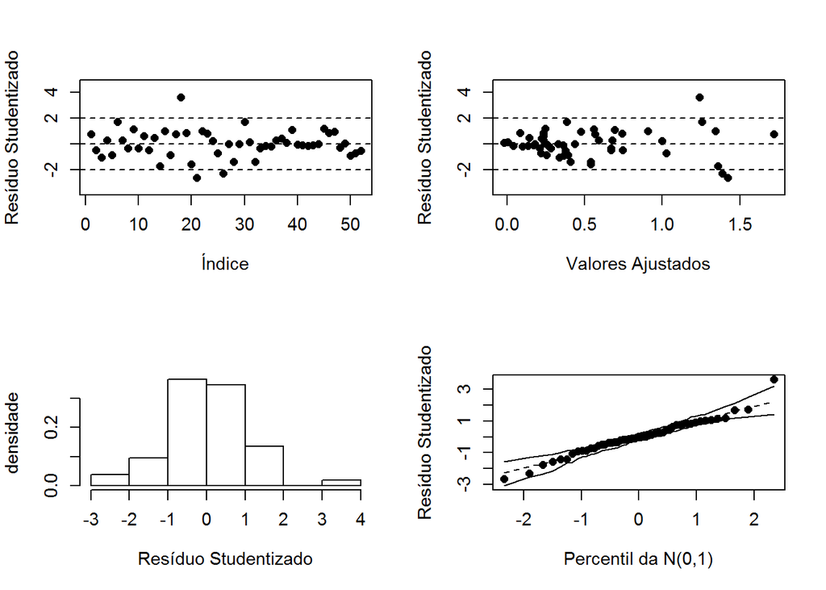

```r
diagnorm(result_compl)
```

Pela análise residual nota-se que há indicios de heterocedasticidade nos dados. QUanto as suposições de normalidade e independência parecem mais compatíveis com os gráficos apresentados.

#### Teste

Consideremos a seguinte hipótese:

$$\beta_{01k}=\beta_{02k}=\beta_{03k}=\beta_{04k}=0$$

Utilizaremos o teste $C\beta=0$ com:

$$C=\begin{bmatrix}
1 & -1 & 0 & 0 & 0 & 0 & 0 & 0\\
1 & 0 & -1 & 0 & 0 & 0 & 0 & 0\\
1 & 0 & 0 & -1 & 0 & 0 & 0 & 0
\end{bmatrix}$$

```r
c=t(matrix(c(1,-1,0,0,0,0,0,0,1,0,-1,0,0,0,0,0,1,0,0,-1,0,0,0,0),8,3))
testeF.CB(result_compl,c)
```

```
## Estatistica F =  0.97
## pvalor =  0.4162
## Matriz C :
##      [,1] [,2] [,3] [,4] [,5] [,6] [,7] [,8]
## [1,]    1   -1    0    0    0    0    0    0
## [2,]    1    0   -1    0    0    0    0    0
## [3,]    1    0    0   -1    0    0    0    0
```

O teste acima não evidencia que os interceptos possam ser diferentes de zero, ou seja, não se rejeitará a hipótese nula.

### Ajustando um modelo sem intercepto

Dada a natureza do problema, pode-se imaginar um modelo sem intercepto pois quando o indice pré-escovação é zero espera que pós-escovação também o seja.

Logo, seja o modelo(ainda considerando o sexo):

$$y_{ijk}=\beta_{1ij}x_{ijk}+\varepsilon_{ijk}$$

$\beta_{1ij}$:Incremento(+/-) quanto se aumenta uma unidade da variável explicativa

$x_{ijk}$: individuo k que escovou com a escova j e é do sexo i

$\varepsilon_{ijk}$:erro amostral

$\varepsilon_{ijk}\sim \mathit{N}(0,\sigma ^{2})$

```r
result_s_i <- lm(ipbpos~-1+(ipbpre:sexotescf))
summary(result_s_i)
```

```
##
## Call:
## lm(formula = ipbpos ~ -1 + (ipbpre:sexotescf))
##
## Residuals:
##      Min       1Q   Median       3Q      Max
## -0.50673 -0.11924 -0.02603  0.13535  0.78472
##
## Coefficients:
##                                Estimate Std. Error t value Pr(>|t|)
## ipbpre:sexotescfF.Convencional  0.46335    0.04482  10.337 8.45e-14 ***
## ipbpre:sexotescfM.Convencional  0.38580    0.02567  15.028  < 2e-16 ***
## ipbpre:sexotescfF.Hugger        0.19704    0.03932   5.011 7.76e-06 ***
## ipbpre:sexotescfM.Hugger        0.14686    0.03526   4.165 0.000129 ***
## ---
## Signif. codes:  0 '***' 0.001 '**' 0.01 '*' 0.05 '.' 0.1 ' ' 1
##
## Residual standard error: 0.2485 on 48 degrees of freedom
## Multiple R-squared:  0.8866, Adjusted R-squared:  0.8771
## F-statistic: 93.79 on 4 and 48 DF,  p-value: < 2.2e-16
```

Observa-se que o desempenho das escovas Hugger são melhores comparados aos da convencional, inpedentemente do sexo.

Obviamente, nota-se uma diminuição do indice de placas mas é natural dada a natureza do experimento pois quando se escova o dente razoavelmente bem, é natural que haja diminuição das placas.

**Matriz de planejamento**

| ipbpre.sexotescfF.Convencional | ipbpre.sexotescfM.Convencional | ipbpre.sexotescfF.Hugger | ipbpre.sexotescfM.Hugger |
| --- | --- | --- | --- |
| 1.20 | 0.00 | 0.00 | 0.00 |
| 1.43 | 0.00 | 0.00 | 0.00 |
| 0.68 | 0.00 | 0.00 | 0.00 |
| 1.45 | 0.00 | 0.00 | 0.00 |
| 0.50 | 0.00 | 0.00 | 0.00 |
| 2.75 | 0.00 | 0.00 | 0.00 |
| 1.25 | 0.00 | 0.00 | 0.00 |
| 0.40 | 0.00 | 0.00 | 0.00 |
| 1.18 | 0.00 | 0.00 | 0.00 |
| 1.43 | 0.00 | 0.00 | 0.00 |
| 0.45 | 0.00 | 0.00 | 0.00 |
| 1.60 | 0.00 | 0.00 | 0.00 |
| 0.25 | 0.00 | 0.00 | 0.00 |
| 2.98 | 0.00 | 0.00 | 0.00 |
| 0.00 | 3.35 | 0.00 | 0.00 |
| 0.00 | 1.50 | 0.00 | 0.00 |
| 0.00 | 4.08 | 0.00 | 0.00 |
| 0.00 | 3.15 | 0.00 | 0.00 |
| 0.00 | 0.90 | 0.00 | 0.00 |
| 0.00 | 1.78 | 0.00 | 0.00 |
| 0.00 | 3.50 | 0.00 | 0.00 |
| 0.00 | 2.50 | 0.00 | 0.00 |
| 0.00 | 2.18 | 0.00 | 0.00 |
| 0.00 | 2.68 | 0.00 | 0.00 |
| 0.00 | 2.73 | 0.00 | 0.00 |
| 0.00 | 3.43 | 0.00 | 0.00 |
| 0.00 | 0.00 | 2.18 | 0.00 |
| 0.00 | 0.00 | 2.05 | 0.00 |
| 0.00 | 0.00 | 1.05 | 0.00 |
| 0.00 | 0.00 | 1.95 | 0.00 |
| 0.00 | 0.00 | 0.28 | 0.00 |
| 0.00 | 0.00 | 2.63 | 0.00 |
| 0.00 | 0.00 | 1.50 | 0.00 |
| 0.00 | 0.00 | 0.45 | 0.00 |
| 0.00 | 0.00 | 0.70 | 0.00 |
| 0.00 | 0.00 | 1.30 | 0.00 |
| 0.00 | 0.00 | 1.25 | 0.00 |
| 0.00 | 0.00 | 0.18 | 0.00 |
| 0.00 | 0.00 | 3.30 | 0.00 |
| 0.00 | 0.00 | 1.40 | 0.00 |
| 0.00 | 0.00 | 0.00 | 0.90 |
| 0.00 | 0.00 | 0.00 | 0.58 |
| 0.00 | 0.00 | 0.00 | 2.50 |
| 0.00 | 0.00 | 0.00 | 2.25 |
| 0.00 | 0.00 | 0.00 | 1.53 |
| 0.00 | 0.00 | 0.00 | 1.43 |
| 0.00 | 0.00 | 0.00 | 3.48 |
| 0.00 | 0.00 | 0.00 | 1.80 |
| 0.00 | 0.00 | 0.00 | 1.50 |
| 0.00 | 0.00 | 0.00 | 2.55 |
| 0.00 | 0.00 | 0.00 | 1.30 |
| 0.00 | 0.00 | 0.00 | 2.65 |

#### Diagnóstico

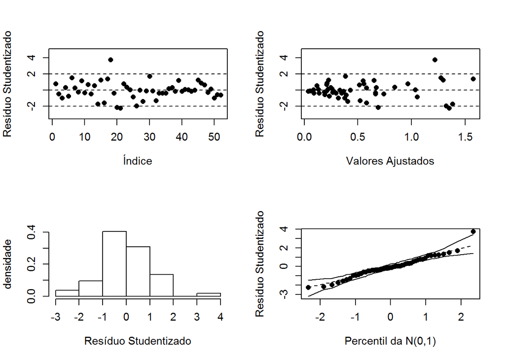

```r
diagnorm(result_s_i)
```

Vemos que hápresença de heterocedasticidade.

#### Testes

Realizaremos o teste $C\beta=0$ para testarmos: $\beta_{1ij}=\beta_{2ij}=\beta_{3ij}=\beta_{4ij}$ com

$$C=\begin{bmatrix}
1 & -1 & 0 & 0\\
1 & 0 & -1 & 0\\
1 & 0 & 0 & -1
\end{bmatrix}$$

```r
(c=t(matrix(c(1,-1,0,0,1,0,-1,0,1,0,0,-1),4,3)))
```

| 1 | -1 | 0 | 0 |
| --- | --- | --- | --- |
| 1 | 0 | -1 | 0 |
| 1 | 0 | 0 | -1 |

```r
testeF.CB(result_s_i,c)
```

```
## Estatistica F =  16.68
## pvalor =  0
## Matriz C :
##      [,1] [,2] [,3] [,4]
## [1,]    1   -1    0    0
## [2,]    1    0   -1    0
## [3,]    1    0    0   -1
```

#### Ajustando um modelo reduzido, desconsiderando o sexo

Dada a análise anterior, façamos um modelo que desconsiderará o sexo como fator de análise.

**Modelo** :

$$y_{ij}=\beta_{0i}+\beta_{1i}x_{ij}+\varepsilon_{ij}$$

$\beta_{0i}$:Valor Esperado quando a quantidade de placa for igual a zero($x_{ij}$=0).

$\beta_{1i}$:Incremento(+/-) quanto se aumenta uma unidade da variável explicativa.

$x_{ij}$: individuo j que escovou com a escova i.

$\varepsilon_{ij}$:erro amostral.

$\varepsilon_{ij}\sim \mathit{N}(0,\sigma ^{2})$

```r
result <- lm(ipbpos~-1+tescf+ipbpre:tescf)
summary(result)
```

```
##
## Call:
## lm(formula = ipbpos ~ -1 + tescf + ipbpre:tescf)
##
## Residuals:
##      Min       1Q   Median       3Q      Max
## -0.56233 -0.13281 -0.00688  0.13732  0.72761
##
## Coefficients:
##                           Estimate Std. Error t value Pr(>|t|)
## tescfConvencional         0.012959   0.101063   0.128  0.89851
## tescfHugger              -0.009596   0.107802  -0.089  0.92944
## tescfConvencional:ipbpre  0.399819   0.046203   8.654 2.31e-11 ***
## tescfHugger:ipbpre        0.173799   0.058074   2.993  0.00436 **
## ---
## Signif. codes:  0 '***' 0.001 '**' 0.01 '*' 0.05 '.' 0.1 ' ' 1
##
## Residual standard error: 0.2564 on 48 degrees of freedom
## Multiple R-squared:  0.8792, Adjusted R-squared:  0.8691
## F-statistic: 87.32 on 4 and 48 DF,  p-value: < 2.2e-16
```

```r
library(printr)
model.result <- data.frame(model.matrix(result))
model.result
```

| tescfConvencional | tescfHugger | tescfConvencional.ipbpre | tescfHugger.ipbpre |
| --- | --- | --- | --- |
| 1 | 0 | 1.20 | 0.00 |
| 1 | 0 | 1.43 | 0.00 |
| 1 | 0 | 0.68 | 0.00 |
| 1 | 0 | 1.45 | 0.00 |
| 1 | 0 | 0.50 | 0.00 |
| 1 | 0 | 2.75 | 0.00 |
| 1 | 0 | 1.25 | 0.00 |
| 1 | 0 | 0.40 | 0.00 |
| 1 | 0 | 1.18 | 0.00 |
| 1 | 0 | 1.43 | 0.00 |
| 1 | 0 | 0.45 | 0.00 |
| 1 | 0 | 1.60 | 0.00 |
| 1 | 0 | 0.25 | 0.00 |
| 1 | 0 | 2.98 | 0.00 |
| 1 | 0 | 3.35 | 0.00 |
| 1 | 0 | 1.50 | 0.00 |
| 1 | 0 | 4.08 | 0.00 |
| 1 | 0 | 3.15 | 0.00 |
| 1 | 0 | 0.90 | 0.00 |
| 1 | 0 | 1.78 | 0.00 |
| 1 | 0 | 3.50 | 0.00 |
| 1 | 0 | 2.50 | 0.00 |
| 1 | 0 | 2.18 | 0.00 |
| 1 | 0 | 2.68 | 0.00 |
| 1 | 0 | 2.73 | 0.00 |
| 1 | 0 | 3.43 | 0.00 |
| 0 | 1 | 0.00 | 2.18 |
| 0 | 1 | 0.00 | 2.05 |
| 0 | 1 | 0.00 | 1.05 |
| 0 | 1 | 0.00 | 1.95 |
| 0 | 1 | 0.00 | 0.28 |
| 0 | 1 | 0.00 | 2.63 |
| 0 | 1 | 0.00 | 1.50 |
| 0 | 1 | 0.00 | 0.45 |
| 0 | 1 | 0.00 | 0.70 |
| 0 | 1 | 0.00 | 1.30 |
| 0 | 1 | 0.00 | 1.25 |
| 0 | 1 | 0.00 | 0.18 |
| 0 | 1 | 0.00 | 3.30 |
| 0 | 1 | 0.00 | 1.40 |
| 0 | 1 | 0.00 | 0.90 |
| 0 | 1 | 0.00 | 0.58 |
| 0 | 1 | 0.00 | 2.50 |
| 0 | 1 | 0.00 | 2.25 |
| 0 | 1 | 0.00 | 1.53 |
| 0 | 1 | 0.00 | 1.43 |
| 0 | 1 | 0.00 | 3.48 |
| 0 | 1 | 0.00 | 1.80 |
| 0 | 1 | 0.00 | 1.50 |
| 0 | 1 | 0.00 | 2.55 |
| 0 | 1 | 0.00 | 1.30 |
| 0 | 1 | 0.00 | 2.65 |

Observa-se que os interceptos parecem ser nulos e os coeficientes angulares sugerem uma superioridade da escova Hugger(quanto menor, melhor).

##### Gráfico

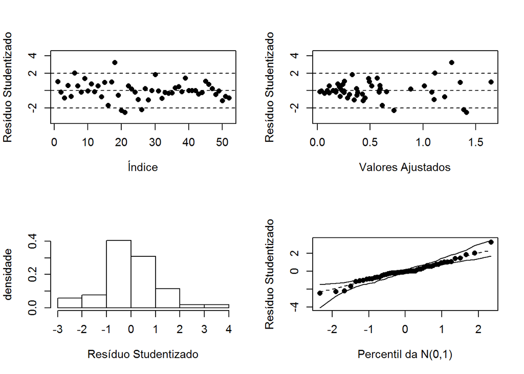

```r
diagnorm(result)
```

Dados os gráficos apresentados acima, observa-se que as suposições homocedasticidade e normalidade não são atendidas pois observa-se no uma tendência em forma de funil no gráfico de Valores Ajustados x Resíduos Studentizados, indicando oscilação de variãncia. No gráfico de Resíduos Studentizados x densidade, observa-se uma leve assimetria dos dados.

Pode-se resolver o problema, modelando os erros por alguma distribuição assimétrica, ou talvez, mesmo por uma Distribuição Normal Heterocedástica.

##### Teste

Consideremos a seguinte hipótese:

$$\beta_{00}=\beta_{01}=0$$

Utilizaremos o teste $C\beta=0$ com

$$C=\begin{bmatrix}
1 & -1 & 0 & 0 & \\
\end{bmatrix}$$

```r
(c=t(matrix(c(1,-1,0,0),4,1)))
```

| 1 | -1 | 0 | 0 |
| --- | --- | --- | --- |

```r
testeF.CB(result,c)
```

```
## Estatistica F =  0.02
## pvalor =  0.8793
## Matriz C :
##      [,1] [,2] [,3] [,4]
## [1,]    1   -1    0    0
```

O teste feito mostra a evidência de que os interceptos são iguais a zero, o que pode levar a construírmos um modelo sem intercepto.

##### Modelos sem intercepto

```r
result_0 <- lm(ipbpos~-1+ipbpre:tescf)
summary(result_0)
```

```
##
## Call:
## lm(formula = ipbpos ~ -1 + ipbpre:tescf)
##
## Residuals:
##      Min       1Q   Median       3Q      Max
## -0.56735 -0.12397 -0.01061  0.14504  0.72438
##
## Coefficients:
##                          Estimate Std. Error t value Pr(>|t|)
## ipbpre:tescfConvencional  0.40496    0.02253  17.972  < 2e-16 ***
## ipbpre:tescfHugger        0.16923    0.02655   6.373 5.73e-08 ***
## ---
## Signif. codes:  0 '***' 0.001 '**' 0.01 '*' 0.05 '.' 0.1 ' ' 1
##
## Residual standard error: 0.2513 on 50 degrees of freedom
## Multiple R-squared:  0.8791, Adjusted R-squared:  0.8743
## F-statistic: 181.8 on 2 and 50 DF,  p-value: < 2.2e-16
```

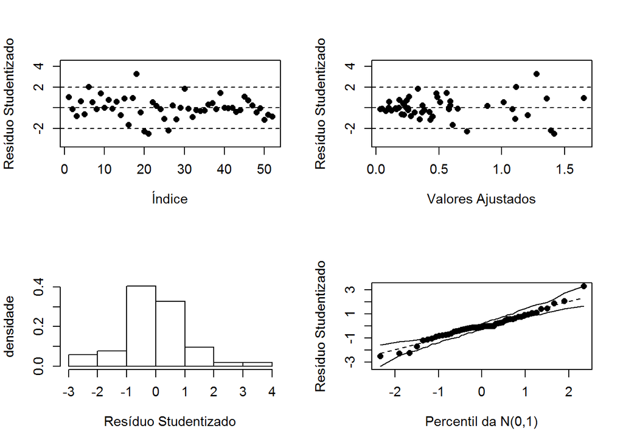

```r
diagnorm(result_0)
```

Presença de Heterocedasticidade

##### Testes

Far-se-á um teste $C\beta=0$ com a seguinte hipótese
$$\beta_{11}=\beta_{12}=0$$
com:

```r
(c=t(matrix(c(1,-1),2,1)))
```

| 1 | -1 |
| --- | --- |

```r
testeF.CB(result_0,c)
```

```
## Estatistica F =  45.82
## pvalor =  0
## Matriz C :
##      [,1] [,2]
## [1,]    1   -1
```

O teste acima evidencia que os interceptos são distintos. Pode-se observar que a estimativa de $\beta_{10}=$ 0.4049577 é maior que a de $\beta_{11}=$ 0.169227, mostrando que a escova Hugger é superior a Convencional(Quanto menor, melhor).

Para estimarmos o ganho do melhor tipo de escova, usaremos o método Delta.

```r
ganho=round(((summary(result_0)$coefficients)[2]/(summary(result_0)$coefficients)[1])*100,1)
```

Ganho obtido: `41.8%.

# Exercício 6

### Análise Descritiva

| Grupo | Media | Dia | Media |
| --- | --- | --- | --- |
| G1 | 26.93750 | 1 | 29.5000 |
| G2 | 34.96875 | 2 | 29.3125 |
| G3 | 29.12500 | 3 | 27.6250 |
| G4 | 25.46875 | 4 | 30.0625 |

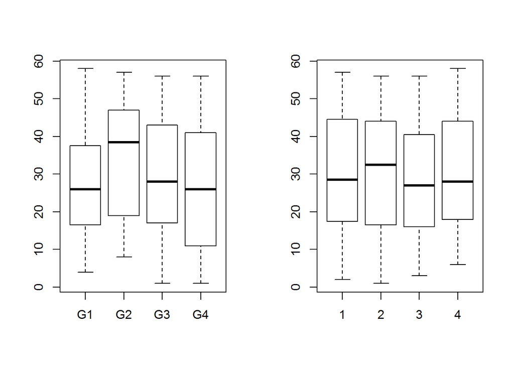

```r
par(mfrow=c(1,2))

boxplot(Antes~factor(Grupo),data=mydata3)

boxplot(Antes~factor(Dia),data=mydata3)
```

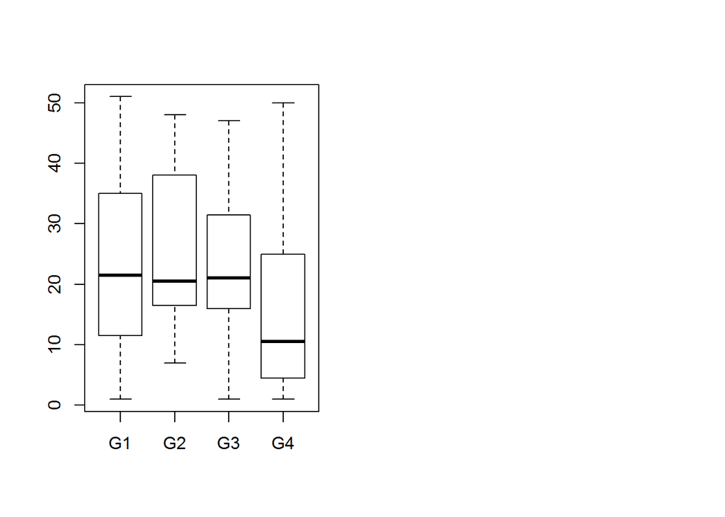

```r
boxplot(Depois~factor(Grupo),data=mydata3)
```

### Ajuste do modelo com intercepto, desconsiderando o dia.

#### Modelo

$$y_{ij}=\beta_{0i}+\beta_{1i}x_{ij}+e_{ij}$$

$\beta_{0i}$ = valor esperado quando o valor do IPB antes é igual a zero.

$\beta_{1i}$ = incremento (+/-) quando se aumenta o valor de $x_{ij}$ em uma unidade.

```r
results = lm((Depois) ~ -1+Grupo + Antes:Grupo, mydata3)
summary(results)
```

```
##
## Call:
## lm(formula = (Depois) ~ -1 + Grupo + Antes:Grupo, data = mydata3)
##
## Residuals:
##     Min      1Q  Median      3Q     Max
## -19.245  -4.530   1.087   4.403  13.835
##
## Coefficients:
##               Estimate Std. Error t value Pr(>|t|)
## GrupoG1       -0.41098    2.66788  -0.154    0.878
## GrupoG2        2.73490    3.10333   0.881    0.380
## GrupoG3        5.38077    2.61743   2.056    0.042 *
## GrupoG4       -3.81967    2.39229  -1.597    0.113
## GrupoG1:Antes  0.88417    0.08753  10.102  < 2e-16 ***
## GrupoG2:Antes  0.64744    0.08125   7.969 1.04e-12 ***
## GrupoG3:Antes  0.61461    0.07899   7.781 2.80e-12 ***
## GrupoG4:Antes  0.77329    0.08013   9.651  < 2e-16 ***
## ---
## Signif. codes:  0 '***' 0.001 '**' 0.01 '*' 0.05 '.' 0.1 ' ' 1
##
## Residual standard error: 7.062 on 120 degrees of freedom
## Multiple R-squared:   0.93,  Adjusted R-squared:  0.9253
## F-statistic: 199.2 on 8 and 120 DF,  p-value: < 2.2e-16
```

Conclui-se também que os grupos 2 e 3 tiveram maior redução em suas taxas que os outros grupos.

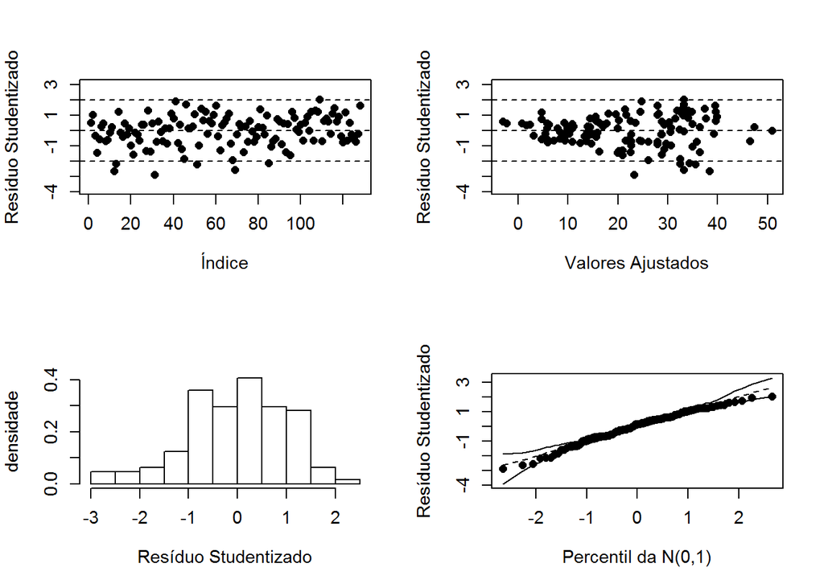

```r
diagnorm(results)
```

Os gráficos indicam a presença de heterocedasticidade. Uma leve assimetria negativa é notada pois o gráfico de resíduso studentizados x densidade apontam para uma leve concentração de dados “à direita” do centro.

#### Testes

Consideremos a seguinte hipótese:

$$\beta_{i0}=\beta_{i1}=\beta_{i3}=\beta_{i4}=0$$

Utilizaremos o teste $C\beta=0$ com
$$C=\begin{bmatrix}
1 & -1 & 0 & 0 & 0 & 0 & 0 & 0\\
1 & 0 & -1 & 0 & 0 & 0 & 0 & 0\\
1 & 0 & 0 & -1 & 0 & 0 & 0 & 0
\end{bmatrix}$$

```r
(c=t(matrix(c(1,-1,0,0,0,0,0,0,1,0,-1,0,0,0,0,0,1,0,0,-1,0,0,0,0),8,3)))
```

| 1 | -1 | 0 | 0 | 0 | 0 | 0 | 0 |
| --- | --- | --- | --- | --- | --- | --- | --- |
| 1 | 0 | -1 | 0 | 0 | 0 | 0 | 0 |
| 1 | 0 | 0 | -1 | 0 | 0 | 0 | 0 |

```r
testeF.CB(results,c)
```

```
## Estatistica F =  2.46
## pvalor =  0.0664
## Matriz C :
##      [,1] [,2] [,3] [,4] [,5] [,6] [,7] [,8]
## [1,]    1   -1    0    0    0    0    0    0
## [2,]    1    0   -1    0    0    0    0    0
## [3,]    1    0    0   -1    0    0    0    0
```

### Ajustando Modelo sem intercepto

```r
results1 = lm((Depois) ~ -1+Antes, mydata3)
summary(results1)
```

```
##
## Call:
## lm(formula = (Depois) ~ -1 + Antes, data = mydata3)
##
## Residuals:
##      Min       1Q   Median       3Q      Max
## -22.1789  -4.4208   0.9309   6.1158  12.5772
##
## Coefficients:
##       Estimate Std. Error t value Pr(>|t|)
## Antes  0.74797    0.01995   37.49   <2e-16 ***
## ---
## Signif. codes:  0 '***' 0.001 '**' 0.01 '*' 0.05 '.' 0.1 ' ' 1
##
## Residual standard error: 7.468 on 127 degrees of freedom
## Multiple R-squared:  0.9171, Adjusted R-squared:  0.9165
## F-statistic:  1405 on 1 and 127 DF,  p-value: < 2.2e-16
```

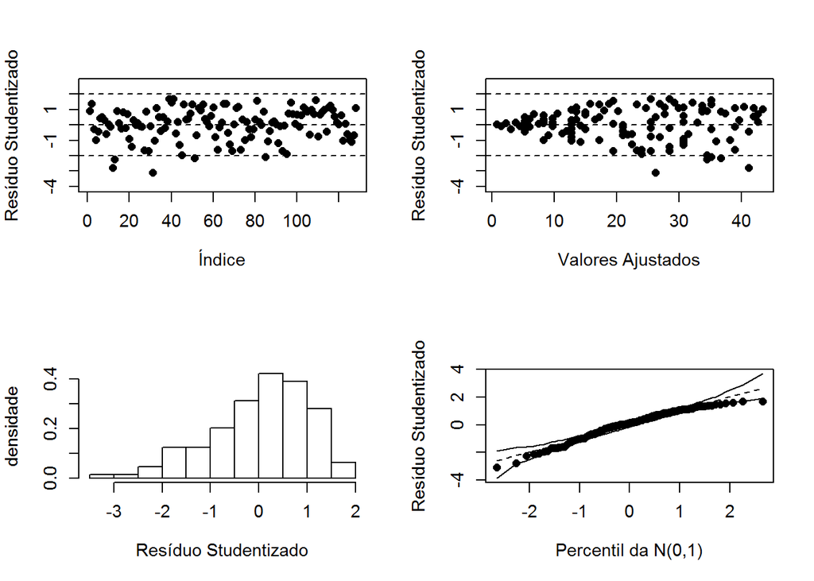

```r
diagnorm(results1)
```